# Week 11 Assignment

# modeling Cars with all of the data

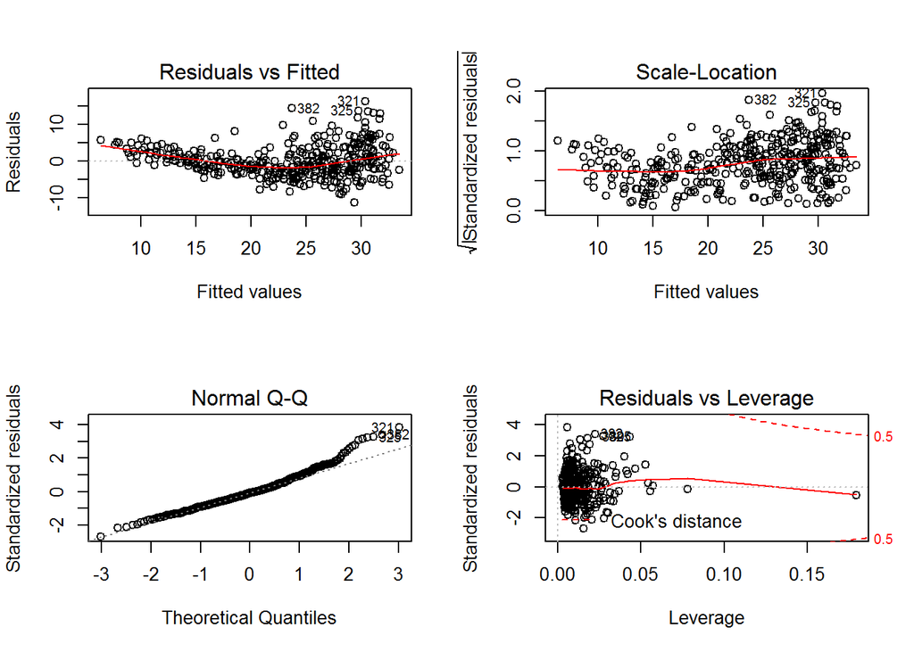

```r
carsfit2 <- lm(mpg ~ displace + horsepwr + weight + acceler, data = df)

yhat <- fitted(carsfit2)

# plots of fit
layout(matrix(c(1,2,3,4),2,2))
plot(carsfit2)
```

```r
b0 <- summary(carsfit2)[4]$coefficients[1,1]
b1 <- summary(carsfit2)[4]$coefficients[2,1]
b2 <- summary(carsfit2)[4]$coefficients[3,1]
b3 <- summary(carsfit2)[4]$coefficients[4,1]
b4 <- summary(carsfit2)[4]$coefficients[5,1]
p0 <- summary(carsfit2)[4]$coefficients[1,4]
p1 <- summary(carsfit2)[4]$coefficients[2,4]
p2 <- summary(carsfit2)[4]$coefficients[3,4]
p3 <- summary(carsfit2)[4]$coefficients[4,4]
p4 <- summary(carsfit2)[4]$coefficients[5,4]
df$yhat  <- yhat

#("displace", "horsepwr", "weight", "acceler", "mpg")

c0 <- confint(carsfit2, '(Intercept)', level=0.95)
c1 <- confint(carsfit2, 'displace', level=0.95)
c2 <- confint(carsfit2, 'horsepwr', level=0.95)
c3 <- confint(carsfit2, 'weight', level=0.95)
c4 <- confint(carsfit2, 'acceler', level=0.95)

dfconf <- data.frame(rbind(c0, c1, c2, c3, c4))
dfconf$coef <- c(b0, b1, b2, b3, b4)
dfconf$pval <- c(p0, p1, p2, p3, p4)
names(dfconf)[1] <- 'interval.low'
names(dfconf)[2] <- 'interval.up'
```

The linear model obtained from the regression using the entire sample is: $mpg = -0.0060009\times displacement + -0.0436077\times horsepower + -0.0052805\times weight + -0.023148 \times acceleration + 45.2511397$

The weight coefficient -0.0052805, horsepower coefficient -0.0436077 and the intercept value 45.2511397 have small p-values of 2.30254510^{-10}, 0.008849 and 7.072099410^{-55} indicating they are significant in modeling the dependent variable, with a significance level greater than 99%. The coefficient for horsepower of -0.0436077 has a significance level of greater than 90% but since it has a high correlation with weight may not provide any information gain.

The summary below of the model shows the standard error and p-value for each of the independent variables used in the model

```r
summary(carsfit2)[4]
```

```
## $coefficients
##                 Estimate   Std. Error    t value     Pr(>|t|)
## (Intercept) 45.251139699 2.4560446927 18.4243959 7.072099e-55
## displace    -0.006000871 0.0067093055 -0.8944102 3.716584e-01
## horsepwr    -0.043607731 0.0165734633 -2.6311779 8.848982e-03
## weight      -0.005280508 0.0008108541 -6.5122789 2.302545e-10
## acceler     -0.023147999 0.1256011622 -0.1842977 8.538765e-01
```

Calculating a 95% confidence interval for each coefficient gives

```r
head(dfconf)
```

```
##             interval.low  interval.up         coef         pval
## (Intercept) 40.422278855 50.080000544 45.251139699 7.072099e-55
## displace    -0.019192122  0.007190380 -0.006000871 3.716584e-01
## horsepwr    -0.076193029 -0.011022433 -0.043607731 8.848982e-03
## weight      -0.006874738 -0.003686277 -0.005280508 2.302545e-10
## acceler     -0.270094049  0.223798050 -0.023147999 8.538765e-01
```

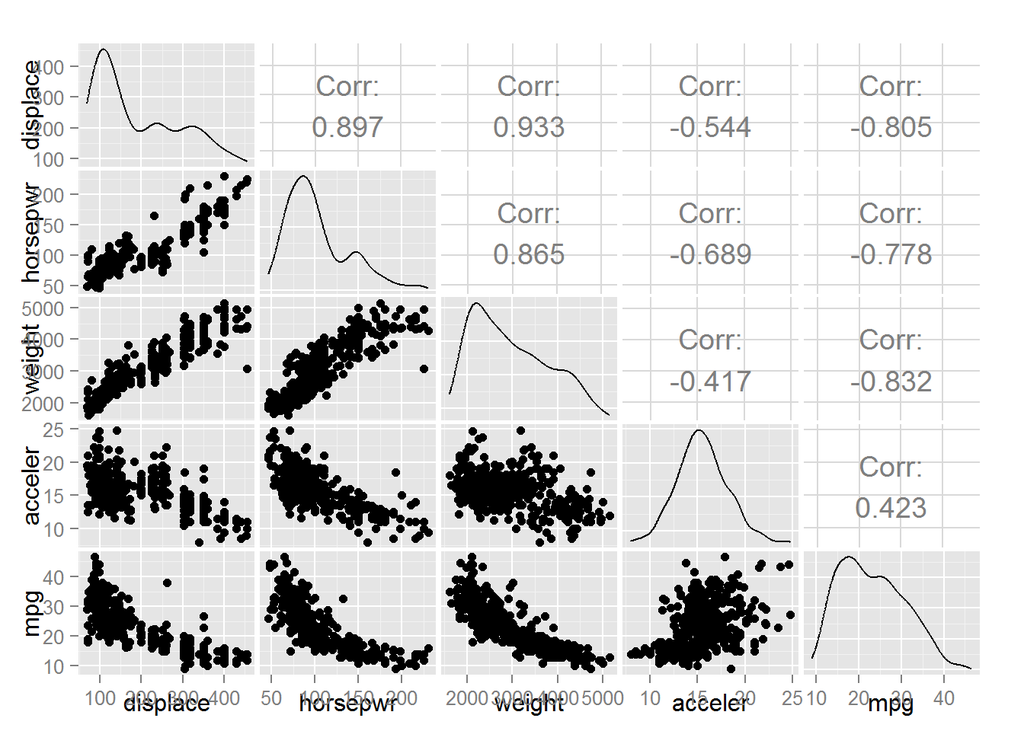

```r
# comparing all data pairwise:

ggpairs(df[,1:5])
```

```r
# model with just weight and horsepower
carsfit3 <- lm(df$mpg ~ df$weight + df$horsepwr)
b0 <- summary(carsfit3)[4]$coefficients[1,1]
b1 <- summary(carsfit3)[4]$coefficients[2,1]
b2 <- summary(carsfit3)[4]$coefficients[3,1]
p0 <- summary(carsfit3)[4]$coefficients[1,4]
p1 <- summary(carsfit3)[4]$coefficients[2,4]
p2 <- summary(carsfit3)[4]$coefficients[3,4]

c0 <- confint(carsfit3, '(Intercept)', level=0.95)
c1 <- confint(carsfit3, 'df$weight', level=0.95)
c2 <- confint(carsfit3, 'df$horsepwr', level=0.95)


dfconf <- data.frame(rbind(c0, c1, c2))
dfconf$coef <- c(b0, b1, b2)
dfconf$pval <- c(p0, p1, p2)
names(dfconf)[1] <- 'interval.low'
names(dfconf)[2] <- 'interval.up'
```

Conclusion: The two most significant predictors of the mpg for the given data are the weight and horsepower of the car. Using all the available variables in a linear model produces an R-squared value of 0.7069812 while using just weight and horsepower give a very similar value for R-squared of 0.7063753

The linear model using just the weight and horsepower becomes: $mpg = -0.0057942\times weight + -0.0473029\times horsepower + 45.6402108$ The summary below of the model shows the standard error and p-value for each of the independent variables used in the model

```r
summary(carsfit3)[4]
```

```
## $coefficients
##                 Estimate  Std. Error    t value      Pr(>|t|)
## (Intercept) 45.640210840 0.793195833  57.539650 2.317113e-192
## df$weight   -0.005794157 0.000502327 -11.534633  1.124362e-26
## df$horsepwr -0.047302863 0.011085086  -4.267253  2.488482e-05
```

Calculating a 95% confidence interval for each coefficient gives

```r
head(dfconf)
```

```
##             interval.low  interval.up         coef          pval
## (Intercept) 44.080723533 47.199698147 45.640210840 2.317113e-192
## df$weight   -0.006781773 -0.004806542 -0.005794157  1.124362e-26
## df$horsepwr -0.069097042 -0.025508684 -0.047302863  2.488482e-05
```